# EPI 569 Final Project

Meghna Ray, Charlotte Doran, and Bevin Manuelpillai

2023-12-13

# Setup

### Load data

```r
raw_data <- readRDS('rff_finalcases_clean_2023_2.rds') %>% janitor::clean_names()
roster <- readRDS('rosters_569_517_clean_2023_2.rds') %>%  janitor::clean_names()
```

### Data Cleaning

```r
linelist <- raw_data %>%
  #rename variables
  rename(c('report' = 'reporting_time',
           'infector_id' = 'infectedby',
           'exposure_date' = 'date_of_exposure',
           'exposure_time' = 'time_of_exposure',
           'symptomatic' = 'did_you_have_symptoms',
           'incubation_period' = 'how_many_hours_after_exposure_did_you_develop_symptoms',
           'illness_duration' = 'how_many_hours_after_your_symptom_onset_did_you_feel_better',
           'n_contacts' = 'how_many_people_did_you_expose',
           'n_infect' = 'how_many_people_did_you_actually_infect',
           'contact1_id' = 'case_id_first_exposure',
           'contact1_date' = 'date_of_first_exposure',
           'contact1_time' = 'time_of_first_exposure',
           'contact2_id' = 'case_id_second_exposure',
           'contact2_date' = 'date_of_second_exposure',
           'contact2_time' = 'time_of_second_exposure',
           'contact3_id' = 'case_id_third_exposure',
           'contact3_date' = 'date_of_third_exposure',
           'contact3_time' = 'time_of_third_exposure',
           'contact4_id' = 'case_id_fourth_exposure',
           'contact4_date' = 'date_of_fourth_exposure',
           'contact4_time' = 'time_of_fourth_exposure',
           'contact5_id' = 'case_id_fifth_exposure',
           'contact5_date' = 'date_of_fifth_exposure',
           'contact5_time' = 'time_of_fifth_exposure',
           'exposure0' = 'date_time_exposure',
           'exposure1' = 'date_time_first_exposure',
           'exposure2' = 'date_time_second_exposure',
           'exposure3' = 'date_time_third_exposure',
           'exposure4' = 'date_time_fourth_exposure',
           'exposure5' = 'date_time_fifth_exposure',
                 'severe_date' = 'date_you_became_severe')) %>%
    mutate(exposure1 = as_datetime(exposure1),
                 exposure2 = as_datetime(exposure2),
                 exposure3 = as_datetime(exposure3),
                 exposure4 = as_datetime(exposure4),
                 exposure5 = as_datetime(exposure4)) %>%

  #recode gender variable as numeric (0 = Female, 1 = Male, 2 = Non-binary)
  mutate(gender = recode(gender, "Female" = 0, "Male" = 1, "Non-binary" = 2)) %>%

  #recode course variable as numeric (0 = EPI 569, 1 = EPI 517, 2 = both)
  mutate(course = recode(course, "EPI 569 (Concepts and Methods in ID EPI)" = 0,
                         "EPI/GH 517 (Case Studies in ID)" = 1,
                         "BOTH" = 2)) %>%

  #recode symptomatic variable as numeric (0 = No, 1 = Yes)
  mutate(symptomatic = recode(symptomatic, "No" = 0, "Yes" = 1)) %>%

    #recode severe variable as numeric (0 = No, 1 = Yes)
    mutate(severe = recode(severe, "No" = 0, "Yes" = 1))
```

### Important values

```r
total_pop <- nrow(roster)
total_cases <- nrow(linelist)
palette <- c(blue = "#66B4BE",
                         green = "#7BA536",
                         red = "#E28571",
                         gray = "#636467",
                         dark_gray = "#49494B",
                         gray_blue = "#1C3052",
                         teal = "#24525A",
                         dark_green = "#35591C",
                         dark_teal = "#0D3840",
                         dark_red = "#722C21",
                         yellow = "#F1A208")
```

# Plot Epi Curve

## Onset and recovery

```r
#Create new onset variable using date and time of exposure + incubation period
med_incubation <- median(linelist$incubation_period, na.rm = TRUE)
med_duration <- median(linelist$illness_duration, na.rm = TRUE)
asymp_duration <- med_incubation + med_duration

#Create onset variable
linelist <- linelist %>%
    mutate(onset_datetime = case_when(symptomatic == 0 ~ NA, #no symptom onset for asymptomatic cases
                                                     symptomatic == 1 ~ exposure0 + hours(incubation_period), #symptoms start after incubation period
                                                     is.na(symptomatic) ~ NA, #keep missing and NA's NA
                                                     TRUE ~ NA)) %>%
  mutate(onset = date(onset_datetime))

#Create recovered variable
linelist <- linelist %>%
    mutate(recovered_datetime = case_when((symptomatic == 0 | is.na(symptomatic)) ~ exposure0 + hours(asymp_duration), #imputed infectious periods for asymptomatic or missing
                                                             (symptomatic == 1 & severe == 1) ~ pmax(onset + hours(illness_duration), severe_date), #for severe cases, recovery is the later of illness duration end or severe date
                                                             (symptomatic == 1 & severe == 0) ~ onset + hours(illness_duration),
                                                             TRUE ~ NA)) %>%
    mutate(recovered = date(recovered_datetime))
```

## Epi curve by onset date

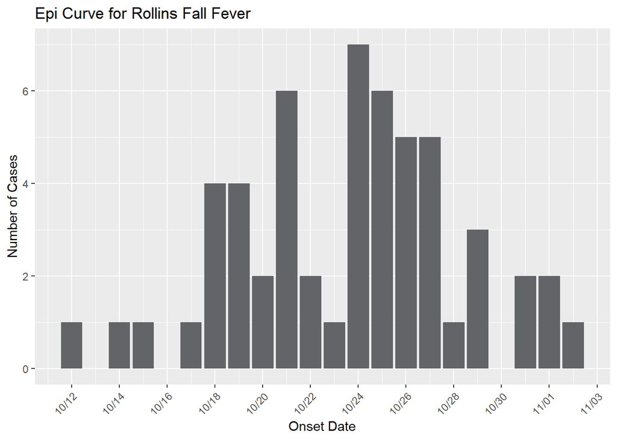

```r
#Create data frame for epi curve with onset and incidence
epicurve1 <- as.data.frame(linelist %>%
                            group_by(onset) %>%
                            summarize(incidence=n()))
#Plot epi curve
plot1 <- epicurve1 %>%
  ggplot(aes(x = onset, y = incidence, labs = FALSE)) +
  geom_bar(stat="identity", fill=palette[4]) +
  scale_x_date(date_breaks = "2 days", date_labels = "%m/%d") +
  scale_y_continuous(breaks = seq(0, 15, by = 2)) +
  theme(axis.text.x = element_text(angle = 45, vjust = 1, hjust = 1)) +
  labs(x = "Onset Date",
       y = "Number of Cases",
       title = "Epi Curve for Rollins Fall Fever")
plot1
```

## Epi curve by exposure date

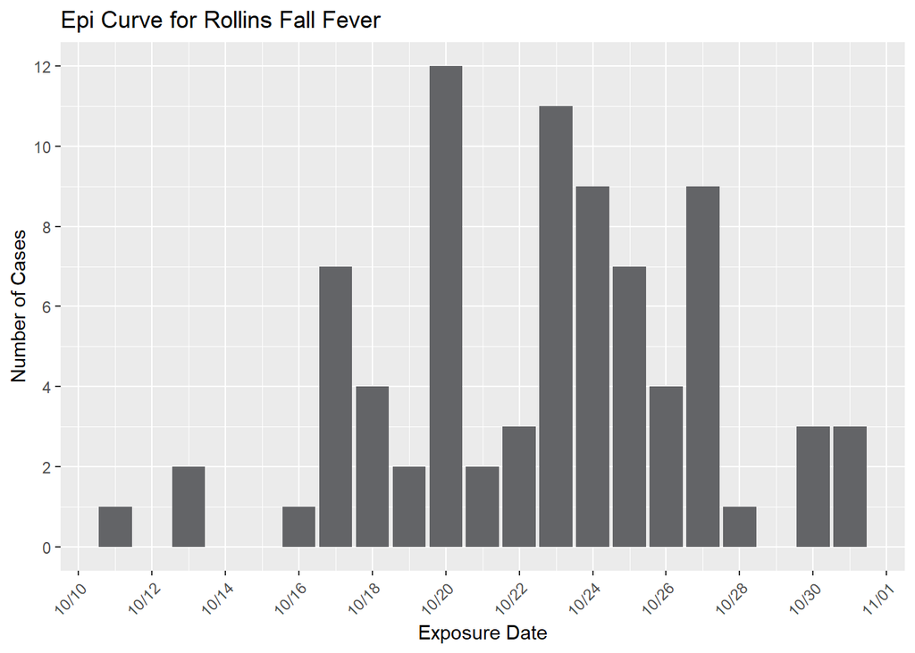

```r
epicurve2 <- as.data.frame(linelist %>%
                            group_by(exposure_date) %>%
                            summarize(incidence=n()))

#Plot epi curve
plot4 <- epicurve2 %>%
  ggplot(aes(x = exposure_date, y = incidence, labs = FALSE)) +
  geom_bar(stat="identity", fill=palette[4]) +
  scale_x_date(date_breaks = "2 days", date_labels = "%m/%d") +
  scale_y_continuous(breaks = seq(0, 15, by = 2)) +
  theme(axis.text.x = element_text(angle = 45, vjust = 1, hjust = 1)) +
  labs(x = "Exposure Date",
       y = "Number of Cases",
       title = "Epi Curve for Rollins Fall Fever")
plot4
```

## Log cases

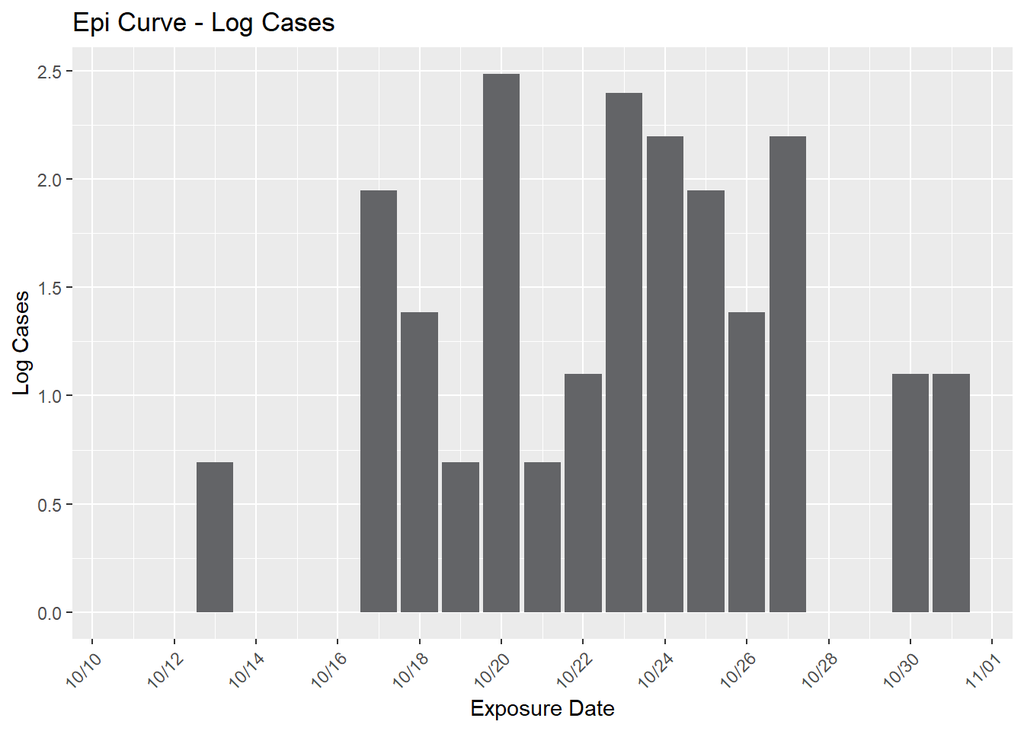

```r
epicurve3 <- epicurve2 %>%
  mutate(log_cases = log(incidence))

#Plot log cases
plot2 <- epicurve3 %>%
  ggplot(aes(x = exposure_date, y = log_cases, labs = FALSE)) +
  geom_bar(stat="identity", fill=palette[4]) +
  scale_x_date(date_breaks = "2 days", date_labels = "%m/%d") +
  scale_y_continuous() +
  theme(axis.text.x = element_text(angle = 45, vjust = 1, hjust = 1)) +
  labs(x = "Exposure Date",
       y = "Log Cases",
       title = "Epi Curve - Log Cases")
plot2
```

## Susceptible, infected, recovered by day

*Calculate number of recovered by day*

```r
recovered <- linelist %>%
  group_by(recovered) %>%
  summarize(n_recovered = n()) %>%
  na.omit()
```

*Calculate number of infected by day*

```r
infected <- linelist %>%
  group_by(exposure_date) %>%
  summarize(n_exposed = n()) %>%
  na.omit()

#Create a sequence of dates from the onset to the end of the outbreak
dateseq <- seq(from = as.Date(min(linelist$exposure_date, na.rm = TRUE)),
                                 to = as.Date(max(linelist$recovered, na.rm = TRUE)),
                                 by = "1 day")

#For each date, calculate the number of infected people by determining if that date is between their onset date and their recovery date
infectedseq <- map(dateseq, ~sum(.x >= linelist$exposure_date & .x < linelist$recovered, na.rm = TRUE))
infected2 <- data.frame(date = dateseq, n_infected = as.numeric(infectedseq))
```

*Calculate number of susceptible by day*

```r
#Join infected and recovered datasets
epicurve4 <- infected2 %>%
  full_join(recovered, by = c("date" = "recovered")) %>%
    full_join(infected, by = c("date" = "exposure_date")) %>%
    #Set na values to zero
  mutate(n_infected = ifelse(is.na(n_infected), 0, n_infected)) %>%
  mutate(n_recovered = ifelse(is.na(n_recovered), 0, n_recovered)) %>%
    mutate(n_exposed = ifelse(is.na(n_exposed), 0, n_exposed)) %>%
    #Create variable for cumulative recoveries and infected
  mutate(total_recovered = cumsum(n_recovered)) %>%
  mutate(total_infected = cumsum(n_exposed))

#Calculate number of people susceptible
epicurve4 <- epicurve4 %>%
  mutate(n_susceptible = total_pop - total_infected) %>%
    #Check that the total population size is stable
    mutate(total = n_infected + total_recovered + n_susceptible)
```

*Plot susceptible, infected, and recovered by day*

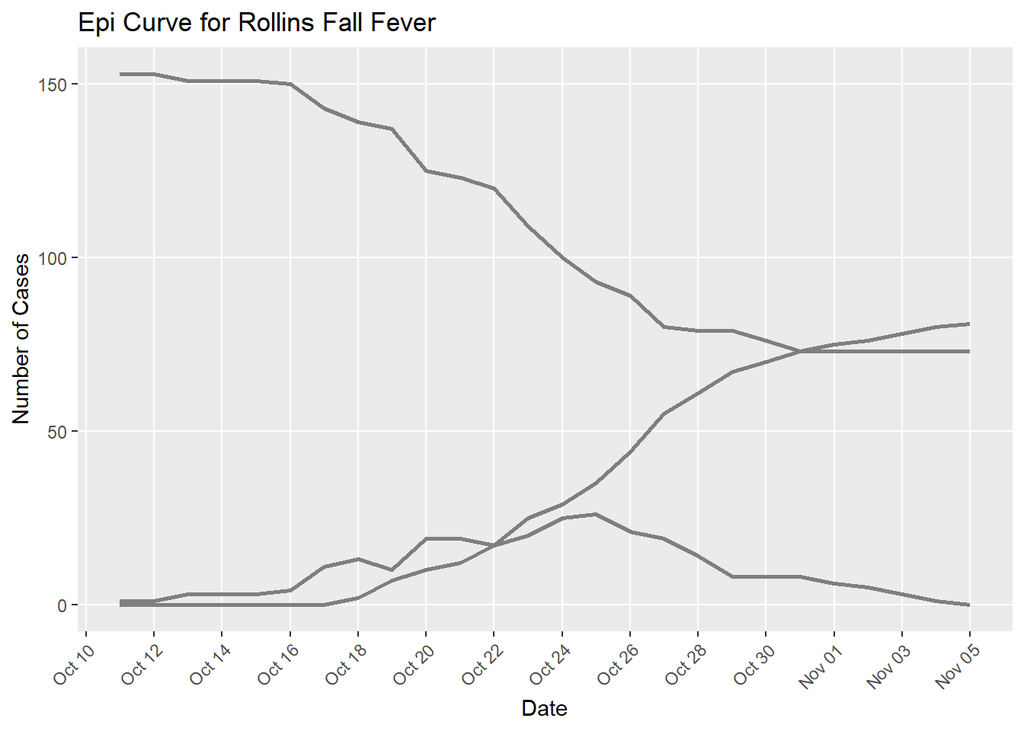

```r
plot3 <- ggplot(epicurve4, aes(x = date)) +
  geom_line(aes(y = n_susceptible, color = "Susceptible"), linewidth = 1) +
  geom_line(aes(y = n_infected, color = "Infected"), linewidth = 1) +
  geom_line(aes(y = total_recovered, color = "Recovered"), linewidth = 1) +
  theme(axis.text.x = element_text(angle = 45, vjust = 1, hjust = 1)) +
  labs(x = "Date",
       y = "Number of Cases",
       title = "Epi Curve for Rollins Fall Fever") +
  scale_color_manual(name='Class',
                     breaks=c('Susceptible', 'Infected', 'Recovered'),
                     values=c('Susceptible'=palette[1], 'Infected'=palette[2], 'Recovered'=palette[3])) +
    scale_x_date(breaks = "2 days",
                             date_labels = "%b %d") +
  theme(legend.title = element_text(size = 15),
        legend.text = element_text(size = 8),
            panel.grid.minor = element_blank())
plot3
```

# Natural History Parameters

**Merge roster and linelist, create new variables**

```r
full_data <- left_join(linelist, roster, by = "case_id")

# Convert to datetime
linelist <- linelist %>%
    mutate(severe_datetime = as_datetime(severe_date))

# #Create datetime Symptom_Onset Variable
# linelist$date_time_symptom_onset <- linelist$exposure0 +
#   as.difftime(linelist$incubation_period, units = "hours")
#
# #Create datetime Recovery_date variable
# linelist$date_time_recovery <- linelist$date_time_symptom_onset +
#   as.difftime(linelist$illness_duration, units = "hours")

#Convert to unambiguous date_time format
# List of variables to convert
# date_time_columns <- c("exposure0", "exposure1", "exposure2", "exposure3", "exposure4", "exposure5", "date_time_symptom_onset", "date_time_recovery", "severe_date")

# #Loop through the list and convert each column
# for (col_name in date_time_columns) {
#   linelist[[col_name]] <- as.POSIXct(linelist[[col_name]], format = "%Y-%m-%d %H:%M:%S")
# }

#Calculate start of infectiousness
linelist <- linelist %>%
  rowwise() %>%
  mutate(infectiousness_start = pmin(exposure1, exposure2, exposure3, exposure4, exposure5, onset_datetime, na.rm = TRUE))

#Calculated end of infectiousness
linelist <- linelist %>%
    rowwise() %>%
    mutate(infectiousness_end = pmax(exposure1, exposure2, exposure3, exposure4, exposure5, recovered_datetime, na.rm = TRUE))

#Calculate case-level infectious period
linelist$infectious_period <- as.numeric(difftime(linelist$infectiousness_end, linelist$infectiousness_start, units = "hours"))

#Calculate case-level latent period
linelist$latent_period <- as.numeric(difftime(linelist$infectiousness_start, linelist$exposure0, units = "hours"))
```

**Subset to Severe and Non-severe RFF**

```r
Severe <- full_data %>%
    filter(severe == 1)

Non_Severe <- full_data %>%
    filter(severe == 0)
```

**Subset linelist to Severe and Non-severe RFF**

```r
Severe_cases <- linelist %>%
    filter(severe == 1)

Non_Severe_cases <- linelist %>%
    filter(severe == 0 & symptomatic == 1)
```

**Subset to Symptomatic and Asymptomatic**

```r
symptomatic <- linelist %>%
  filter(symptomatic == 1)

asymptomatic <- linelist %>%
  filter(symptomatic == 0)

nonsevere_symptomatic <- linelist %>%
  filter(symptomatic == 1 & severe != 1)
```

## Incubation period

```r
mean_incubation <- mean(linelist$incubation_period, na.rm = T)
#23.36

sd_incubation <- sd(linelist$incubation_period, na.rm = T)
#7.38
```

**Incubation period for Severe cases and Non_severe cases**

```r
mean_incubation_severe <- mean(Severe_cases$incubation_period)
#23.43

sd_incubation_severe <- sd(Severe_cases$incubation_period)
#6.38

mean_incubation_nonsevere <- mean(Non_Severe_cases$incubation_period)
#23.30

sd_incubation_nonsevere <- sd(Non_Severe_cases$incubation_period)
#8.43
```

**Natural history among non-severe symptomatic cases

```r
#incubation period
mean(nonsevere_symptomatic$incubation_period)
```

```
## [1] 23.2963
```

```r
sd(nonsevere_symptomatic$incubation_period)
```

```
## [1] 8.425304
```

```r
#latent period
mean(nonsevere_symptomatic$latent_period)
```

```
## [1] 16.60309
```

```r
sd(nonsevere_symptomatic$latent_period)
```

```
## [1] 10.4015
```

```r
#duration of illness
mean(nonsevere_symptomatic$illness_duration)
```

```
## [1] 25.66667
```

```r
sd(nonsevere_symptomatic$illness_duration)
```

```
## [1] 8.435274
```

```r
#infectious period
mean(nonsevere_symptomatic$infectious_period)
```

```
## [1] 35.16852
```

```r
sd(nonsevere_symptomatic$infectious_period)
```

```
## [1] 31.88812
```

**Latent period for asymptomatic cases and symptomatic cases**

```r
mean(symptomatic$latent_period)
```

```
## [1] 16.47455
```

```r
#18.03
sd(symptomatic$latent_period)
```

```
## [1] 10.41688
```

```r
#9.25
mean(asymptomatic$latent_period, na.rm = T)
```

```
## [1] 11.88571
```

```r
#15.89
sd(asymptomatic$latent_period, na.rm = T)
```

```
## [1] 11.08497
```

```r
#11.08
```

## Illness duration

```r
mean_duration <- mean(linelist$illness_duration, na.rm = T)
#25.02

ds_duration <- sd(linelist$illness_duration, na.rm = T)
#9.09
```

## Infectious Period

```r
#Calculate infectious period
mean_infectious <- mean(linelist$infectious_period, na.rm = TRUE)
mean_infectious
```

```
## [1] 66.11613
```

```r
#66.1
sd_infectious <- sd(linelist$infectious_period, na.rm = TRUE)
sd_infectious
```

```
## [1] 43.8974
```

```r
#43.9
```

## Latent Period

```r
mean_latent <- mean(linelist$latent_period, na.rm = TRUE)
mean_latent
```

```
## [1] 15.95645
```

```r
#16.0
sd_latent <- sd(linelist$latent_period, na.rm = TRUE)
sd_latent
```

```
## [1] 10.50186
```

```r
#10.5
```

## Natural History Stratified by Severity

```r
# Infectious Period for Severe
mean_infectious_severe <- mean(Severe_cases$infectious_period, na.rm = TRUE)
sd_infectious_severe <- sd(Severe_cases$infectious_period, na.rm = TRUE)

# Infectious Period for not severe
mean_infectious_nonsevere <- mean(Non_Severe_cases$infectious_period, na.rm = TRUE)
sd_infectious_nonsevere <- sd(Non_Severe_cases$infectious_period, na.rm = TRUE)

# Latent Period for Severe
mean_latent_severe <- mean(Severe_cases$latent_period, na.rm = TRUE)
sd_latent_severe <- sd(Severe_cases$latent_period, na.rm = TRUE)
```

**Mean and SD for Infectious Period Stratified by symptom status**

```r
# Infectious Period for symptomatic
mean_infectious_symptomatic <- mean(symptomatic$infectious_period, na.rm = TRUE)
#69.7
sd_infectious_symptomatic <- sd(symptomatic$infectious_period, na.rm = TRUE)
#45.3

# Infectious Period for asymptomatic
mean_infectious_asymptomatic <- mean(asymptomatic$infectious_period, na.rm = TRUE)
#38.1
sd_infectious_asymptomatic <- sd(asymptomatic$infectious_period, na.rm = TRUE)
#11.1
```

## Serial Interval

**Serial Interval (By symptom onset date)**

```r
#Get infector and infected columns
merged_data <- merge(linelist, linelist, by.x = "infector_id", by.y = "case_id", suffixes = c("_infected", "_infector"))

#Calculate serial interval in days
merged_data$serial_interval_in_days <-
    as.numeric(difftime(merged_data$onset_datetime_infected,
                                            merged_data$onset_datetime_infector,
                                            units = "days"))

serial_interval_in_days_average <- mean(merged_data$serial_interval_in_days, na.rm = T)
#1.81
serial_interval_in_days_sd <- sd(merged_data$serial_interval_in_days, na.rm = T)
#2.18

#Calculate serial interval in hours
merged_data$serial_interval_in_hours <-
    as.numeric(difftime(merged_data$onset_datetime_infected,
                                            merged_data$onset_datetime_infector,
                                            units = "hours"))

serial_interval_in_hours_average <- mean(merged_data$serial_interval_in_hours, na.rm = T)
#43.5
serial_interval_in_hours_sd <- sd(merged_data$serial_interval_in_hours, na.rm = T)
#52.2
```

**Serial Interval (By Infectiousness End Date)**

```r
#Calculate serial interval in days
merged_data$serial_interval_in_days2 <-
    as.numeric(difftime(merged_data$infectiousness_end_infected,
                                            merged_data$infectiousness_end_infector,
                                            units = "days"))

serial_interval_in_days_average2 <- mean(merged_data$serial_interval_in_days2, na.rm = T)
#1.20
serial_interval_in_days_sd2 <- sd(merged_data$serial_interval_in_days2, na.rm = T)
#2.48

#Calculate serial interval in hours
merged_data$serial_interval_in_hours2 <-
    as.numeric(difftime(merged_data$infectiousness_end_infected,
                                            merged_data$infectiousness_end_infector,
                                            units = "hours"))

serial_interval_in_hours_average2 <- mean(merged_data$serial_interval_in_hours2, na.rm = T)
#28.9
serial_interval_in_hours_sd2 <- sd(merged_data$serial_interval_in_hours2, na.rm = T)
#59.64
```

**Serial interval (By infectiousness start date)**

```r
#Calculate serial interval in hours
merged_data$serial_interval_in_hours3 <-
    as.numeric(difftime(merged_data$infectiousness_start_infected,
                                            merged_data$infectiousness_start_infector,
                                            units = "hours"))

serial_interval_in_hours_average3 <- mean(merged_data$serial_interval_in_hours3, na.rm = T)
#41.8
serial_interval_in_hours_sd3 <- sd(merged_data$serial_interval_in_hours3, na.rm = T)
#46.5
```

## Generating Plots for Incubation Period

```r
#Filter incubation period
incubation_duration <- linelist$incubation_period[!(is.na(linelist$incubation_period)) & linelist$incubation_period > 0]

#Fit distribution
incubation_fit_ln_duration <- fitdist(incubation_duration, "lnorm")
summary(incubation_fit_ln_duration)
```

```
## Fitting of the distribution ' lnorm ' by maximum likelihood
## Parameters :
##          estimate Std. Error
## meanlog 3.0866460 0.05281525
## sdlog   0.3916884 0.03734493
## Loglikelihood:  -196.2563   AIC:  396.5125   BIC:  400.5272
## Correlation matrix:
##               meanlog         sdlog
## meanlog  1.000000e+00 -1.401461e-11
## sdlog   -1.401461e-11  1.000000e+00
```

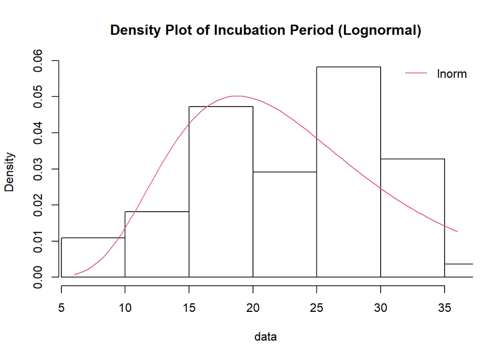

```r
#Plot
denscomp(incubation_fit_ln_duration, main = "Density Plot of Incubation Period (Lognormal)")
```

## Generating Plots for Illness Duration

```r
#Filter illness periods
illness_duration <- linelist$illness_duration[!(is.na(linelist$illness_duration)) & linelist$illness_duration > 0]

#Fit distribution
illness_fit_ln_duration <- fitdist(illness_duration, "lnorm")

summary(illness_fit_ln_duration)
```

```
## Fitting of the distribution ' lnorm ' by maximum likelihood
## Parameters :
##          estimate Std. Error
## meanlog 3.1441717 0.05561949
## sdlog   0.4124852 0.03932788
## Loglikelihood:  -202.2655   AIC:  408.5311   BIC:  412.5458
## Correlation matrix:
##         meanlog sdlog
## meanlog       1     0
## sdlog         0     1
```

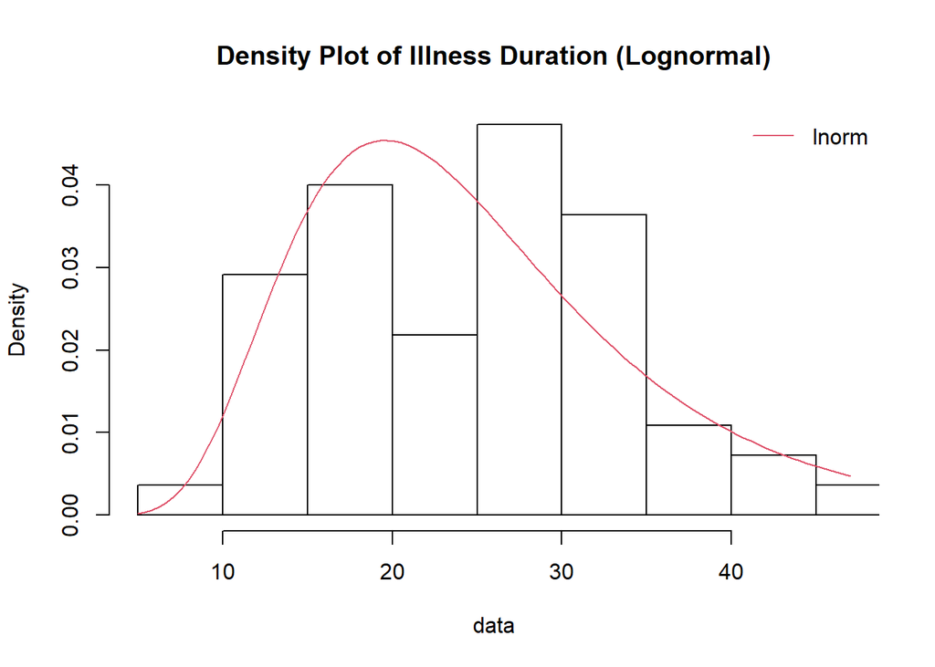

```r
#Plot
denscomp(illness_fit_ln_duration, main = "Density Plot of Illness Duration (Lognormal)")
```

## Generating Plots for Infectious Period

```r
#Filter Infectious periods
infectious_duration <- linelist$infectious_period[!(is.na(linelist$infectious_period)) & linelist$infectious_period > 0]

#Fit distribution
infectious_fit_ln_duration <- fitdist(infectious_duration, "lnorm")

summary(infectious_fit_ln_duration)
```

```
## Fitting of the distribution ' lnorm ' by maximum likelihood
## Parameters :
##         estimate Std. Error
## meanlog 3.898204 0.10793017
## sdlog   0.849843 0.07631768
## Loglikelihood:  -319.5752   AIC:  643.1504   BIC:  647.4047
## Correlation matrix:
##         meanlog sdlog
## meanlog       1     0
## sdlog         0     1
```

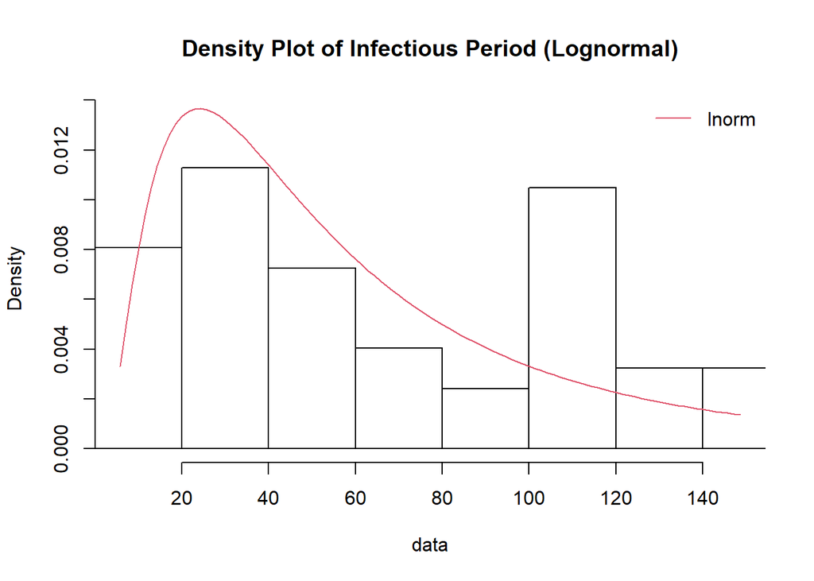

```r
#Plot
denscomp(infectious_fit_ln_duration, main = "Density Plot of Infectious Period (Lognormal)")
```

```r
#Filter Infectious periods
serial_interval_in_hours <-
    merged_data$serial_interval_in_hours[!(is.na(merged_data$serial_interval_in_hours))
                                                                             & merged_data$serial_interval_in_hours > 0]
#Fit distribution
serial_interval_fit_ln_duration <- fitdist(serial_interval_in_hours, "lnorm")


summary(serial_interval_fit_ln_duration)
```

```
## Fitting of the distribution ' lnorm ' by maximum likelihood
## Parameters :
##         estimate Std. Error
## meanlog 3.255652  0.2000278
## sdlog   1.341827  0.1414406
## Loglikelihood:  -223.588   AIC:  451.176   BIC:  454.7894
## Correlation matrix:
##         meanlog sdlog
## meanlog       1     0
## sdlog         0     1
```

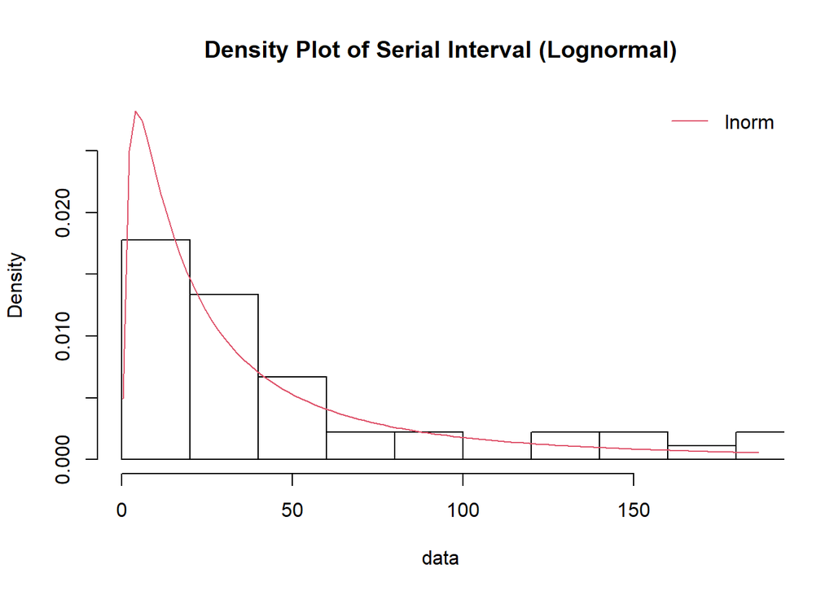

```r
#Plot
denscomp(serial_interval_fit_ln_duration, main = "Density Plot of Serial Interval (Lognormal)")
```

Log Distribution of Natural History Parameters

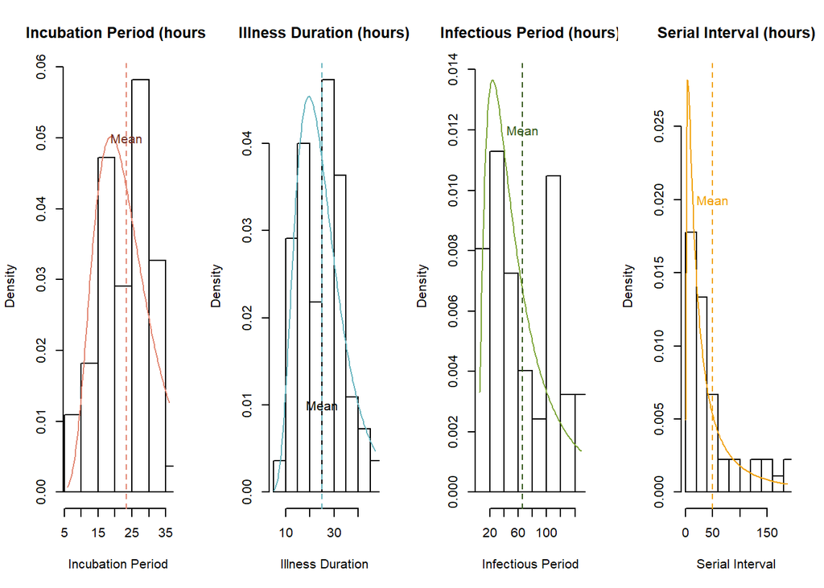

```r
#Create Graph
par(mfrow=c(1,4))

#Incubation Period
# incubation_duration <- linelist$incubation_period[!(is.na(linelist$incubation_period)) & linelist$incubation_period > 0]
# incubation_fit_ln_duration <- fitdist(incubation_duration, "lnorm")

#Plot
denscomp(incubation_fit_ln_duration,
                 main = "Incubation Period (hours)",
                 xlab = "Incubation Period",
                 ylab = "Density",
                 fitcol = palette["red"],
                 addlegend = FALSE)
abline(v = mean(incubation_duration),
             col = palette["red"],
             lty = 2)
text(mean(incubation_duration), 0.05, "Mean", col = palette["dark_red"])

#Illness Duration
# illness_duration <- linelist$illness_duration[!(is.na(linelist$illness_duration)) & linelist$illness_duration > 0]
# illness_fit_ln_duration <- fitdist(illness_duration, "lnorm")

#Plot
denscomp(illness_fit_ln_duration,
                 main = "Illness Duration (hours)",
                 xlab = "Illness Duration",
                 ylab = "Density",
                 fitcol = palette["blue"],
                 addlegend = FALSE)
abline(v = mean(illness_duration),
             col = palette["blue"],
             lty = 2)
text(mean(illness_duration), 0.01, "Mean", col = palette["dark_blue"])

#Infectious Period
# infectious_duration <- linelist$infectious_period[!(is.na(linelist$infectious_period))
#                                                                                                   & linelist$infectious_period > 0]
# infectious_fit_ln_duration <- fitdist(infectious_duration, "lnorm")

#Plot
denscomp(infectious_fit_ln_duration,
                 main = "Infectious Period (hours)",
                 xlab = "Infectious Period",
                 ylab = "Density",
                 fitcol = palette["green"],
                 addlegend = FALSE)
abline(v = mean(infectious_duration),
             col = palette["dark_green"],
             lty = 2)
text(mean(infectious_duration), 0.012, "Mean", col = palette["dark_green"])

#Serial Interval
# serial_interval_in_hours <-
#   merged_data$serial_interval_in_hours[!(is.na(merged_data$serial_interval_in_hours)) &
#                                                                               merged_data$serial_interval_in_hours > 0]
# serial_interval_fit_ln_duration <- fitdist(serial_interval_in_hours, "lnorm")

#Plot
denscomp(serial_interval_fit_ln_duration,
                 main = "Serial Interval (hours)",
                 xlab = "Serial Interval",
                 ylab = "Density",
                 fitcol = palette["yellow"],
                 addlegend = FALSE)
abline(v = mean(serial_interval_in_hours),
             col = palette["yellow"],
             lty = 2)
text(mean(serial_interval_in_hours), 0.02, "Mean", col = palette["yellow"])
```

**Log Distribution of Natural History Parameters (Combined)**

[figure not shown]

```r
#Create Graph
par(mfrow=c(1,1))

#Incubation Period
# incubation_duration <- linelist$incubation_period[!(is.na(linelist$incubation_period)) & linelist$incubation_period > 0]
# incubation_fit_ln_duration <- fitdist(incubation_duration, "lnorm")
#
# #Illness Duration
# illness_duration <- linelist$illness_duration[!(is.na(linelist$illness_duration)) & linelist$illness_duration > 0]
# illness_fit_ln_duration <- fitdist(illness_duration, "lnorm")
#
# #Infectious Period
# infectious_duration <- linelist$infectious_period[!(is.na(linelist$infectious_period)) & linelist$infectious_period > 0]
# infectious_fit_ln_duration <- fitdist(infectious_duration, "lnorm")
#
# #Serial Interval
# serial_interval_in_hours <- merged_data$serial_interval_in_hours[!(is.na(merged_data$serial_interval_in_hours)) & merged_data$serial_interval_in_hours > 0]
# serial_interval_fit_ln_duration <- fitdist(serial_interval_in_hours, "lnorm")

#X-axis setting
max_duration <- max(c(max(incubation_duration), max(illness_duration), max(infectious_duration), max(serial_interval_in_hours)))

#Incubation Period
denscomp(incubation_fit_ln_duration,
                 main = "Combined Density Plot",
                 xlab = "Time (days)",
                 ylab = "Density",
                 xlim = c(0, max_duration),
                 fitcol = palette["red"],
                 fitlty = 2,
                 fitlwd = 2)
#Illness Duration
lines(density(illness_duration), col = palette["blue"], lty = 2, lwd = 2)  # Adjust the line thickness with lwd parameter

#Infectious Period
lines(density(infectious_duration), col = palette["green"], lty = 2, lwd = 2)  # Adjust the line thickness with lwd parameter

#Serial Interval
lines(density(serial_interval_in_hours), col = palette["yellow"], lty = 2, lwd = 2)  # Adjust the line thickness with lwd parameter

#Legend
legend("topright", legend = c("Incubation", "Illness", "Infectious", "Serial Interval"), col = palette[c("red", "blue", "green", "yellow")], lty = 2, lwd = 2, cex = 0.8)
```

# Demographic Information

**Compare Period Prevalence of Undergraduates and Graduate Year 1 vs those that are Graduate Year 2 and #doctorate students**

```r
#Create new variable to dichotomize level variable
#Get numerator
full_data <- full_data %>%
    mutate(education = ifelse(level %in% c("Graduate Year 1", "Senior"),0,1))

table(full_data$education)
```

```
##
##  0  1
## 44 37
```

```r
# 44 = 0 and 37 = 1
#Get Denominator
roster <- roster %>%
    mutate(education = ifelse(level %in% c("Graduate Year 1", "Senior"),0,1))

table(roster$education)
```

```
##
##  0  1
## 64 90
```

```r
# 64 = 0 and 90 = 1

period_prevalance_G1S <- sum(full_data$education == 0)/sum(roster$education == 0)
period_prevalance_G2D <- sum(full_data$education == 1)/sum(roster$education == 1)
```

**Compare Period Prevalence of RFF for different PH programs**

```r
table(roster$program)
```

```
##
##           Behavioral Sciences                 Biostatistics
##                             3                             1
## Envirnmnt Health-Epidemiology          Environmental Health
##                             4                             3
##                  Epidemiology   Global Environmental Health
##                            75                             6
##           Global Epidemiology                 Global Health
##                            29                            29
##               Human Health BA      Special Standing Student
##                             1                             3
```

```r
roster <- roster %>%
  mutate(program_num = ifelse(program == "Epidemiology", 0,
                              ifelse(program == "Global Epidemiology", 1,
                                     ifelse(program == "Global Health", 2, 3))))

table(roster$program_num)
```

```
##
##  0  1  2  3
## 75 29 29 21
```

```r
full_data <- full_data %>%
    mutate(program_num = ifelse(program == "Epidemiology", 0,
                              ifelse(program == "Global Epidemiology", 1,
                                     ifelse(program == "Global Health", 2, 3))))
table(full_data$program_num)
```

```
##
##  0  1  2  3
## 38 18 12 13
```

```r
period_prevalance_epi = 38/75
period_prevalance_glepi = 18/29
period_prevalance_gh = 12/29
period_prevalance_otherprs = 13/21
```

## Severity by Demographic Factors

```r
#Severity by Course
table(full_data$education)
```

```
##
##  0  1
## 44 37
```

```r
table(Severe$education)
```

```
## < table of extent 0 >
```

```r
#Severity by Program
table(full_data$program_num)
```

```
##
##  0  1  2  3
## 38 18 12 13
```

```r
table(Severe$program_num)
```

```
## < table of extent 0 >
```

## Population Sizes

```r
table(roster$course)
```

```
##
##              EPI 569 EPI 569 & Epi/GH 517           EPI/GH 517
##                   54                    5                   95
```

```r
#EPI_569 = 54, EPI 517 = 95, EPI 569 + EPI 517 = 5

table(roster$degree)
```

```
##
##          Doctor of Philosophy       Liberal Arts & Sciences
##                             4                             1
##       Master of Public Health Master of Science Public Hlth
##                           136                            10
##      Non-Degree Public Health
##                             3
```

```r
#Doctor of Philosphy = 4, Liberal Arts & Sciences = 1, Master of Public Health = 136, Master of Science Public Health = 10, Non-Degree Public Health = 3

table(roster$program)
```

```
##
##           Behavioral Sciences                 Biostatistics
##                             3                             1
## Envirnmnt Health-Epidemiology          Environmental Health
##                             4                             3
##                  Epidemiology   Global Environmental Health
##                            75                             6
##           Global Epidemiology                 Global Health
##                            29                            29
##               Human Health BA      Special Standing Student
##                             1                             3
```

```r
#Behavioral Sciences = 3, Biostatistics = 1, Environmental Health + Epidemiology = 4, Environmental Health = 3, Epidemiology = 75, Global Environmental Health = 6, Global Epidemiology = 29, Global Health = 29, Human Health BA = 1, Special Standing Student = 3.

table(roster$level)
```

```
##
##       Full Standing     Graduate Year 1     Graduate Year 2 Non-Degree Graduate
##                   4                  63                  83                   3
##              Senior
##                   1
```

```r
#full standing = 4, Graduate Year 1 = 63, Graduate Year 2 = 83, Non-Degree Graduate = 3, Senior = 1
```

## Case Distribution

```r
table(full_data$course.y)
```

```
##
##              EPI 569 EPI 569 & Epi/GH 517           EPI/GH 517
##                   28                    4                   49
```

```r
#EPI 569 = 28 cases, EPI 517 = 49 cases, Both = 4

table(linelist$gender)
```

```
##
##  0  1  2
## 49 17  2
```

```r
#Female = 49 cases, Male = 17 cases, Non-Binary = 2

table(Severe$gender)
```

```
##
##  0  1
## 20  8
```

```r
#Females = 20 severe cases, Males = 8 severe cases
```

## Illness Duration in severe cases

```r
mean(Severe$illness_duration)
```

```
## [1] 24.39286
```

```r
sd(Severe$illness_duration)
```

```
## [1] 9.795461
```

## Compare infectiousness between symptomatic and asymptomatic cases

```r
symptomatic <- linelist %>%
    filter(symptomatic == 1)

asymptomatic <- linelist %>%
    filter(symptomatic == 0)
#Symptomatic R0
mean(symptomatic$n_contacts)
```

```
## [1] 2.381818
```

```r
sd(symptomatic$n_contacts)
```

```
## [1] 1.312206
```

```r
#Asympomatic R0
mean(asymptomatic$n_contacts)
```

```
## [1] 0.7692308
```

```r
sd(asymptomatic$n_contacts)
```

```
## [1] 0.7250111
```

# Reproduction Numbers

```r
start_day <- date("2023-10-11")
end_day <- date("2023-10-20")
```

We used the initial growth rate method to calculate $R_0$ from the plot of the log cases based on exposure date. The first case on RFF was observed on 2023-10-11. Using the plot of log cases, the log-linear growth period ends on 2023-10-20. $I(t) \approx I(0) e^{rt}$

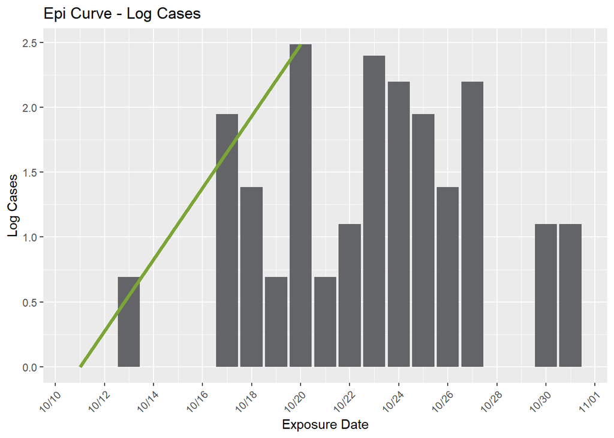

```r
linear_growth <- epicurve3 %>%
    filter(exposure_date %in% c(start_day, end_day))
plot2 +
    geom_line(data = linear_growth,
                        mapping = aes(x = exposure_date, y = log_cases),
                        color = palette[2],
                        linewidth = 1.5)
```

```r
r0_df <- epicurve3 %>%
    filter(exposure_date >= start_day, exposure_date <= end_day) %>%
    splitstackshape::expandRows("incidence", drop = FALSE) %>%
    dplyr::select(exposure_date) %>%
    pull(exposure_date)

i <- incidence(r0_df)
mu <- serial_interval_in_days_average #replace with mean generation time
sigma <- serial_interval_in_days_sd #replace with standard deviation of generation time
res <- get_R(i, si_mean = mu, si_sd = sigma)
R_val <- sample_R(res, 1000)
r0 <- mean(R_val)
#2.41 (changes with each run)
```

Based on the initial growth rate, the basic reproductive number for RFF, $R_0$, is 2.4.

We can compare this value to the $R_0$ calculated based purely on the number of people that each individual exposed.

```r
r0_2 <- mean(linelist$n_contacts, na.rm = TRUE)
#2.04

#By symptom status
r0_3 <- linelist %>%
    group_by(symptomatic) %>%
    summarize(r0 = mean(n_contacts, na.rm = TRUE),
                        count = n())

#By severity
r0_4 <- linelist %>%
    group_by(severe) %>%
    summarize(r0 = mean(n_contacts, na.rm = TRUE),
                        count = n())
```

# Modeling

## SEIR Equations

$\frac{dS}{dt} = -\lambda_t S$

$\frac{dE}{dt} = \lambda_t S - \gamma E$

$\frac{dI}{dt} = \gamma E - \sigma I$

$\frac{dR}{dt} = \sigma I$

## Waning Immunity Equations

$\frac{dS}{dt} = \omega R -\lambda_t S$

$\frac{dE}{dt} = \lambda_t S - \gamma E$

$\frac{dI}{dt} = \gamma E - 0.65 \sigma I - 0.35 \sigma I$

$\frac{dR}{dt} = 0.65 \sigma I - \omega R$

$\frac{dR_s}{dt} = 0.35 \sigma I$

## Observed Data

```r
mean_duration <- mean(linelist$illness_duration, na.rm = TRUE)
#25.02

mean_latent <- mean(linelist$latent_period, na.rm = TRUE)
#15.96
```

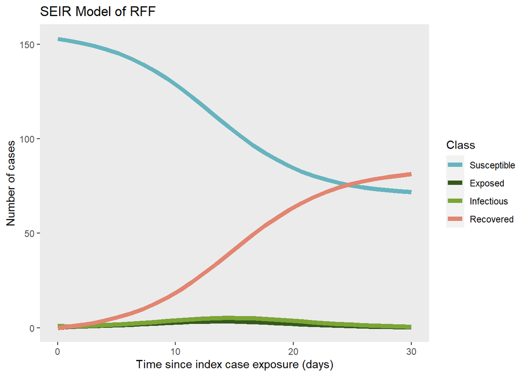

```r
#Create function for model equations
sir_ode <- function(times,init,parms){
  with(as.list(c(parms,init)), {
    # ODEs
    dS <- - (alpha*beta*I*S/(S+E+I+R))
    dE <- (alpha*beta*I*S/(S+E+I+R)) - (gamma*E)
    dI <- (gamma*E) - (sigma*I)
    dR <- (sigma*I)
    list(c(dS,dE,dI,dR))
  })
}

#Define parameters
parms <- c(alpha = 5,              # alpha = daily contacts
           beta = 0.275,             # beta = probability of infection on contact
                     gamma = 1/(mean_latent/24),  # gamma = rate of infectiousness onset
           sigma = 1/(mean_duration/24))# sigma = rate of recovery per day

#Set initial conditions
init <- c(S = 153,
                    E = 0,
                    I = 1,
                    R = 0)

times <- seq(0, 30, length.out=30)
sir_out <- lsoda(init,times,sir_ode,parms)
sir_out_long <- melt(as.data.frame(sir_out),"time")

#Plot the model output
sir_out_long %>% ggplot(aes(x=time, y=value, colour=variable, group=variable)) +
    geom_line(lwd = 2) +
  labs(x = "Time since index case exposure (days)",
         y = "Number of cases",
         title = "SEIR Model of RFF") +
    scale_color_manual(name = "Class",
                                         breaks = c("S", "E", "I", "R"),
                                         labels = c("Susceptible",
                                                            "Exposed",
                                                            "Infectious",
                                                            "Recovered"),
                                         values = c("S" = as.character(palette["blue"]),
                                                             "E" = as.character(palette["dark_green"]),
                                                             "I" = as.character(palette["green"]),
                                                             "R" = as.character(palette["red"]))) +
    theme(panel.grid = element_blank())
```

```r
as.numeric(sir_out_long %>%
    filter(variable == "R") %>%
    summarize(max(value)))
```

```
## [1] 81.29739
```

## Waning Immunity

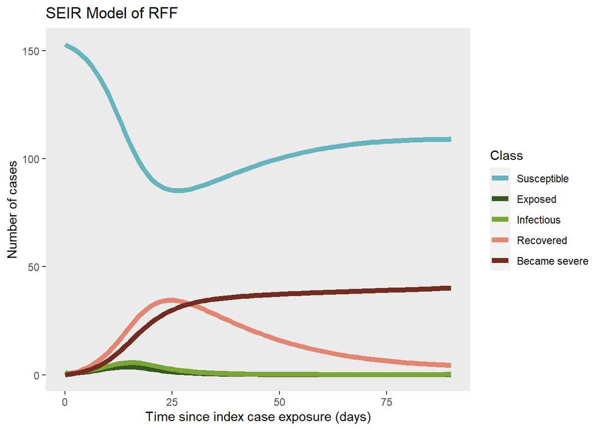

```r
#Create function for model equations
sir_ode <- function(times,init,parms){
  with(as.list(c(parms,init)), {
    # ODEs
    dS <- (omega*R) - (S*alpha*beta*I/(S+E+I+R+R_s))
    dE <- (S*alpha*beta*I/(S+E+I+R+R_s)) - (gamma*E)
    dI <- (gamma*E) - (0.65*sigma*I) - (0.35*mu*I)
    dR <- (0.65*sigma*I)  - (omega*R)
    dRs <- 0.35*mu*I
    list(c(dS,dE,dI,dR,dRs))
  })
}

#Define parameters
parms <- c(alpha = 5,              # alpha = daily contacts
           beta = 0.275,             # beta = probability of infection on contact
                     gamma = 1/(mean_latent/24),  # gamma = rate of infectiousness onset
           sigma = 1/(mean_duration/24),# sigma = rate of recovery per day
           mu = 1/(mean_duration/24),   # mu = rate of severe disease
           omega = 1/20)            # omega = rate of immune loss per day

#Set initial conditions
init <- c(S = 153,
                    E = 0,
                    I = 1,
                    R = 0,
                    R_s = 0)

times <- seq(0, 90, length.out=90)
sir_out <- lsoda(init,times,sir_ode,parms)
sir_out_long <- melt(as.data.frame(sir_out),"time")

#Plot the model output
sir_out_long %>% ggplot(aes(x=time, y=value, colour=variable, group=variable)) +
    geom_line(lwd = 2) +
  labs(x = "Time since index case exposure (days)",
         y = "Number of cases",
         title = "SEIR Model of RFF") +
    scale_color_manual(name = "Class",
                                         breaks = c("S", "E", "I", "R", "R_s"),
                                         labels = c("Susceptible",
                                                            "Exposed",
                                                            "Infectious",
                                                            "Recovered",
                                                            "Became severe"),
                                         values = c("S" = as.character(palette["blue"]),
                                                             "E" = as.character(palette["dark_green"]),
                                                             "I" = as.character(palette["green"]),
                                                             "R" = as.character(palette["red"]),
                                                             "R_s" = as.character(palette["dark_red"]))) +
    theme(panel.grid = element_blank())
```

```r
as.numeric(sir_out_long %>%
    filter(variable == "R") %>%
    summarize(max(value))) +
    as.numeric(sir_out_long %>%
    filter(variable == "R_s") %>%
    summarize(max(value)))
```

```
## [1] 74.68779
```

# Time-varying Reproductive Number (Rt)

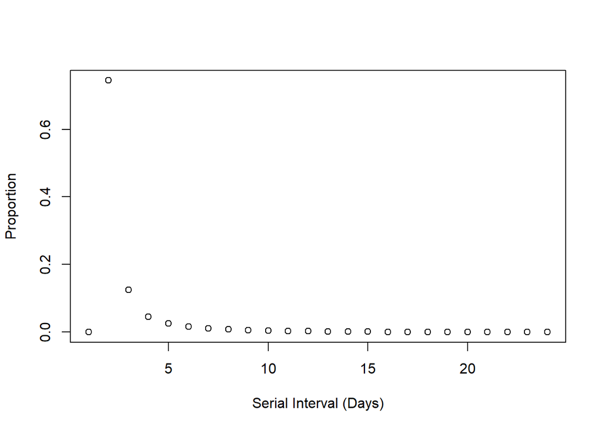

```r
#Convert data to a format that can be used in the EpiEstim wallinga_teunis function
## Note: to calculate an Rt estimate for day 1 of the outbreak, we must start our epi curve 2 days prior the first symptom onset date

epicurve5 <- epicurve2 %>%
    arrange(exposure_date) %>%
    rename(date = exposure_date, I = incidence) %>%
    dplyr::select(date, I)

all.dates <- as.data.frame(seq(as.Date("2023-10-09"), by = "day", length.out = 23))
names(all.dates) <- "date"

epicurve.epiestim <- merge(x=epicurve5, y=all.dates, by="date", all="TRUE")
epicurve.epiestim <- epicurve.epiestim %>% mutate(I = ifelse(is.na(I), 0, I))

#Estimate Rt, along with 95% confidence intervals for Rt estimates

mean_si_days <- 41.12/24
std_si_days <- 47.15/24

estimates <- wallinga_teunis(epicurve.epiestim$I,
                             method="parametric_si",
                             config = list(t_start = seq(1, 23),
                                           t_end = seq(1, 23),
                                           mean_si = mean_si_days,
                                           std_si = std_si_days,
                                           n_sim = 1000))

#save estimates R to a new dataframe
#set zeros for where estimates are missing

estimates_R <- as.data.frame(estimates$R)


estimates_R <- as.data.frame(estimates$R) %>%
    rename(mean = `Mean(R)`,
                 std = `Std(R)`,
                 Q25 = `Quantile.0.025(R)`,
                 Q975 = `Quantile.0.975(R)`) %>%
    rbind(data.frame(t_start = c(6, 7, 21),
                                     t_end = c(6, 7, 21),
                                     mean = 0,
                                     std = 0,
                                     Q25 = 0,
                                     Q975 = 0)) %>%
    arrange(t_start)

#Examine the serial interval distribution
plot(estimates$si_distr, xlab="Serial Interval (Days)", ylab="Proportion")
```

Plot the R(t) estimates and 95% CIs over the epi curve

```r
plot2.data <- cbind(epicurve.epiestim[-(1:4),], estimates_R$mean,
                    estimates_R$Q25, estimates_R$Q975)
names(plot2.data) <- c("dates", "I", "R", "lowerCI", "upperCI")
```

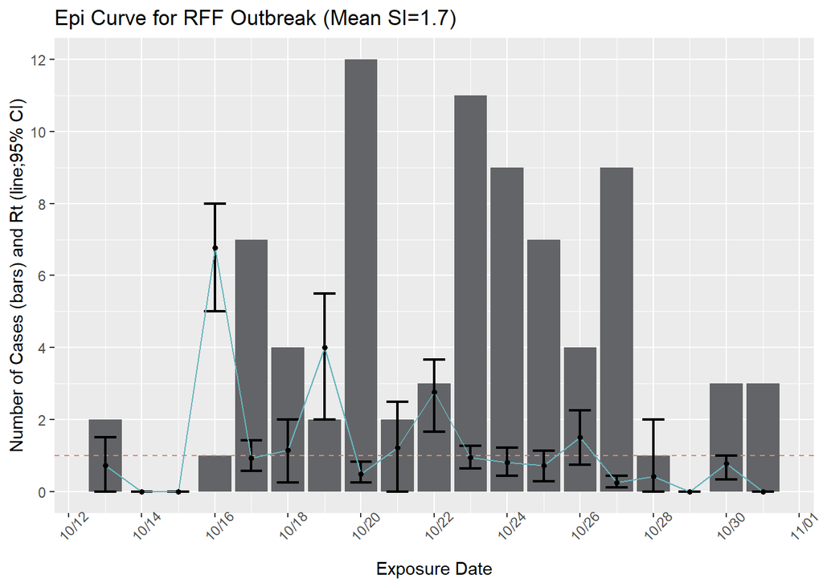

```r
plot2 <- ggplot(data=plot2.data, aes(x=dates, y=I, labs=FALSE)) +
  geom_bar(stat="identity", fill="#636467") +
  scale_x_date(date_breaks = "2 days", date_labels = "%m/%d") +
  scale_y_continuous(breaks = seq(0,20, by = 2)) +
  theme(axis.text.x = element_text(angle = 45)) +
  labs(x = "Exposure Date",
       y = "Number of Cases (bars) and Rt (line;95% CI)",
       title = "Epi Curve for RFF Outbreak (Mean SI=1.7)") +
  geom_hline(aes(yintercept=1), colour=palette["red"], linetype="dashed", size=0.5) +
  geom_errorbar(data=plot2.data, aes(ymax=upperCI, ymin=lowerCI, width=0.6),stat="identity", size=0.8, show.legend=FALSE) +
  geom_line(data=plot2.data[!is.na(plot2.data$R),],aes(x=dates, y=R), color=palette["blue"], size=0.5) +
  geom_point(data = plot2.data, aes(x=dates, y=R), size=1.2, show.legend=FALSE)
plot2
```

# Calculate critical vaccination thresholds

$P_c = (1 - 1/R_0) / VE$

$HIT = (1 - 1/R_0)$

$P_c = HIT / VE$

$R_0 = 2.41$

```r
R0 <- 2.41
HIT <- 1 - (1/R0)
HIT
```

```
## [1] 0.5850622
```

```r
#VE = 100%
Pc_100 <- (HIT/1) *100
Pc_100
```

```
## [1] 58.50622
```

```r
#VE = 90%
Pc_90 <- (HIT/0.9) *100
Pc_90
```

```
## [1] 65.00692
```

```r
#VE = 80%
Pc_80 <- (HIT/0.8) *100
Pc_80
```

```
## [1] 73.13278
```

```r
#VE = 70%
Pc_70 <- (HIT/0.7) *100
Pc_70
```

```
## [1] 83.58032
```

```r
#VE = 60%
Pc_60 <- (HIT/0.6) *100
Pc_60
```

```
## [1] 97.51037
```

```r
#VE = 50%
Pc_50 <- (HIT/0.5) *100
Pc_50
```

```
## [1] 117.0124
```

```r
#VE = 50%
Pc_40 <- (HIT/0.4) *100
Pc_40
```

```
## [1] 146.2656
```